# For loops and the apply family

Stephanie Thiede

11/15/2019

### 1. R basics - vectors, matrices, lists, logicals

#### A. Vectors - 1D arrays:

##### Initialize a vector

Two examples of how to initialize a vector

```r
my_vec = c(1,2,3,4,5,6,7,8,9,10)
my_vec
```

```
##  [1]  1  2  3  4  5  6  7  8  9 10
```

```r
my_vec = 1:10
my_vec
```

```
##  [1]  1  2  3  4  5  6  7  8  9 10
```

##### Initialize an empty vector

How to initialize an empty vector, to store things in later

```r
my_vec = vector(mode = 'numeric', length = 10 )
my_vec
```

```
##  [1] 0 0 0 0 0 0 0 0 0 0
```

#### B. Matrices/data frames - 2D arrays:

##### Initialize a matrix

Initialize a matrix called my_mat

```r
my_mat = matrix(1:10, ncol = 2, nrow = 5)
my_mat
```

```
##      [,1] [,2]
## [1,]    1    6
## [2,]    2    7
## [3,]    3    8
## [4,]    4    9
## [5,]    5   10
```

```r
class(my_mat)
```

```
## [1] "matrix"
```

Name the rows and columns using colnames() and row.names()

```r
colnames(my_mat) = c('A', 'B')
row.names(my_mat) = c('Sample1', 'Sample2', 'Sample3', 'Sample4', 'Sample5')

my_mat
```

```
##         A  B
## Sample1 1  6
## Sample2 2  7
## Sample3 3  8
## Sample4 4  9
## Sample5 5 10
```

Get the dimensions of my_mat. Dimensions are reported as c(row, column) where numbers of rows in the first bin, and number of columns in the second bin

```r
dim(my_mat)
```

```
## [1] 5 2
```

Can also ask for the number of rows and number of columns directly with ncol() and nrow()

```r
ncol(my_mat)
```

```
## [1] 2
```

```r
nrow(my_mat)
```

```
## [1] 5
```

Can see the column names and row names of my_mat with rownames() and colnames()

```r
#get the column names of my_mat
colnames(my_mat)
```

```
## [1] "A" "B"
```

```r
#get the row names of my_mat
rownames(my_mat)
```

```
## [1] "Sample1" "Sample2" "Sample3" "Sample4" "Sample5"
```

##### Access rows/columns in matrices

Format is: my_mat[row, column]

Can access with numeric indices

```r
# row 2, column 1
my_mat[2,1]
```

```
## [1] 2
```

Can access with row names and column names

```r
# row 2, column 1
my_mat['Sample2','A']
```

```
## [1] 2
```

Get all rows, 2nd column. Don’t specify a row, just use a comma

```r
# all rows, 2nd column
my_mat[,2]
```

```
## Sample1 Sample2 Sample3 Sample4 Sample5
##       6       7       8       9      10
```

Get all columns, 1st row. Don’t specify a column, just use a comma

```r
# all columns, 1st row
my_mat[1,]
```

```
## A B
## 1 6
```

##### C. Data frames

Initialize a data frame

```r
my_df = data.frame(A = c(1,2,3,4,5), B = c(6,7,8,9,10), row.names = c('Sample1', 'Sample2', 'Sample3', 'Sample4', 'Sample5'))

my_df
```

```
##         A  B
## Sample1 1  6
## Sample2 2  7
## Sample3 3  8
## Sample4 4  9
## Sample5 5 10
```

```r
# get the class -- data.frame
class(my_df)
```

```
## [1] "data.frame"
```

Indexing dataframes is the same as matrices, but you can also index the columns using the $.

3 ways to access column A, the first column

```r
my_df[,'A']
```

```
## [1] 1 2 3 4 5
```

```r
my_df[,1]
```

```
## [1] 1 2 3 4 5
```

```r
my_df$A #can't do this with matrices!
```

```
## [1] 1 2 3 4 5
```

#### D. Lists

Each element of a list can contain vectors, matrices, lists, etc. of any shape or size.

Here, we have a list where the first element will be a vector, the second is a matrix, and the third is a data.frame

```r
my_list = list(my_vec, my_mat, my_df)

my_list
```

```
## [[1]]
##  [1] 0 0 0 0 0 0 0 0 0 0
##
## [[2]]
##         A  B
## Sample1 1  6
## Sample2 2  7
## Sample3 3  8
## Sample4 4  9
## Sample5 5 10
##
## [[3]]
##         A  B
## Sample1 1  6
## Sample2 2  7
## Sample3 3  8
## Sample4 4  9
## Sample5 5 10
```

##### Accessing element of a list

Use double square brackets to access a list element. Here, we’re accessing the first element of my_list.

```r
my_list[[1]]
```

```
##  [1] 0 0 0 0 0 0 0 0 0 0
```

##### Acess content with a list element

Access the second element of the list

```r
my_list[[2]]
```

```
##         A  B
## Sample1 1  6
## Sample2 2  7
## Sample3 3  8
## Sample4 4  9
## Sample5 5 10
```

Then you can subset it with matrix subsetting (since its a matrix)

```r
my_list[[2]][1,1]
```

```
## [1] 1
```

```r
my_list[[2]]['Sample1','A']
```

```
## [1] 1
```

##### Subsetting a list

Subset a list with single square brackets. This will make your list a length of 2 – containing only the 1st and 3rd elements of my_list()

```r
my_list[c(1,3)]
```

```
## [[1]]
##  [1] 0 0 0 0 0 0 0 0 0 0
##
## [[2]]
##         A  B
## Sample1 1  6
## Sample2 2  7
## Sample3 3  8
## Sample4 4  9
## Sample5 5 10
```

#### E. Subsetting a data frame with logicals

Say, your samples in my_df came from the following sources: either dog or cat as such.

```r
sample_source = c('cat', 'dog', 'cat', 'cat', 'dog')
```

See how the length of sample_source is the same as the number of rows in my_df – as each sample is either from “dog” or “cat”

```r
length(sample_source)
```

```
## [1] 5
```

```r
dim(my_df)
```

```
## [1] 5 2
```

Create a logical vector – ask “where does sample source equal cat”. Will give TRUE when sample_source is cat and FALSE when sample_source is dog.

```r
sample_source == 'cat'
```

```
## [1]  TRUE FALSE  TRUE  TRUE FALSE
```

See that the class is a logical

```r
class(sample_source == 'cat')
```

```
## [1] "logical"
```

We can subset the column ‘A’ in my_df on cat samples using the logical vector.

```r
my_df$A[sample_source == 'cat']
```

```
## [1] 1 3 4
```

Similarily, we can subset my_df on the dog samples using another logical vector – and use comma to indicate we want all the columns.

```r
my_df[sample_source == 'dog',]
```

```
##         A  B
## Sample2 2  7
## Sample5 5 10
```

### 2. Iterating through vectors and matrices with for loops

#### A. Structure of a for loop

for (thing in sequence){

do thing

}

#### B. Examples

```r
colors = c('red', 'blue', 'green')
```

```r
for (i in 1:length(colors)){

  print(colors[i])

}
```

```
## [1] "red"
## [1] "blue"
## [1] "green"
```

```r
for (thing in colors){

  print(thing)

}
```

```
## [1] "red"
## [1] "blue"
## [1] "green"
```

### 3. Vectorized vs. sapply vs. for loop

```r
# Vector of circle radii
radii = 1:100000
```

```r
# Function for area of a circle
area_of_circle <- function(r){
  return(pi * r^2)
}
```

```r
# Example of using the function
area_of_circle(r = 10)
```

```
## [1] 314.1593
```

#### A. Vectorized

```r
start = Sys.time()

areas_method1 = area_of_circle(radii)

end = Sys.time()

end - start
```

```
## Time difference of 0.004391909 secs
```

#### B. sapply()

```r
start = Sys.time()

areas_method2 = sapply(radii, area_of_circle)

end = Sys.time()

end - start
```

```
## Time difference of 0.08914495 secs
```

#### C. for loop

```r
start = Sys.time()

areas_method3 = vector(mode = 'numeric', length = length(radii))

for (i in 1:length(radii)){
  areas_method3[i] = area_of_circle(radii[i])
}
end = Sys.time()

end - start
```

```
## Time difference of 0.06706595 secs
```

To summarize:

- vectorized code is faster than sapply() and for loops
- for loops and sapply() are similar in speed, depending on the length of the vector and the task
- for loops completes same task in multiple lines of code, vectorization & sapply in 1 line of code so you might want to use an apply family function for clarigy

Let’s explore with examples.

### 4. Looping over a vector or list: sapply() or lapply()

```r
tv_data = read.csv('data/IMDb_Economist_tv_ratings.csv', stringsAsFactors = FALSE)
```

```r
max_season = rep(NA, length(unique(tv_data$title)))
for (i in 1:length(unique(tv_data$title))){
  show = unique(tv_data$title)[i]
  max_season[i] = (max(tv_data$seasonNumber[tv_data$title == show]))
}
names(max_season) = unique(tv_data$title)
```

```r
max_season = sapply(unique(tv_data$title), function(show){
  max(tv_data$seasonNumber[tv_data$title == show])
})


#hist(max_season, breaks = seq(0,45,1))
```

#### can output a vector

```r
max_season = sapply(unique(tv_data$title), function(show){
  max(tv_data$seasonNumber[tv_data$title == show])
})

head(max_season)
```

```
##             11.22.63           12 Monkeys       13 Reasons Why
##                    1                    4                    2
##                   24           24: Legacy 24: Live Another Day
##                    8                    1                    1
```

```r
#hist(max_season, breaks = seq(0,45,1))
```

### can output a list

```r
avg_rating_per_show = sapply(unique(tv_data$title), function(show){
  tv_data$av_rating[tv_data$title == show]
})
head(avg_rating_per_show)
```

```
## $`11.22.63`
## [1] 8.489
##
## $`12 Monkeys`
## [1] 8.3407 8.8196 9.0369 9.1363
##
## $`13 Reasons Why`
## [1] 8.4370 7.5089
##
## $`24`
## [1] 8.5641 8.7028 8.7173 8.5610 8.7828 8.3522 8.4922 8.4744
##
## $`24: Legacy`
## [1] 7.2044
##
## $`24: Live Another Day`
## [1] 8.899
```

### can output a matrix

subset on those with 2 seasons:

```r
num_seasons = sapply(unique(tv_data$title), function(show){
  length(tv_data$seasonNumber[tv_data$title == show])
})
```

```r
two_seasons = unique(tv_data$title)[num_seasons == 2]
avg_rating_two_seasons = sapply(two_seasons, function(show){
  (tv_data$av_rating[tv_data$title == show])
})

avg_rating_two_seasons
```

```
##      13 Reasons Why 7th Heaven A Series of Unfortunate Events Alphas
## [1,]         8.4370        7.7                         8.1052 7.6436
## [2,]         7.5089        6.3                         8.2873 7.8699
##      American Crime Story American Gothic American Vandal Aquarius Atlanta
## [1,]               8.7267           7.800          8.1528   7.5292  8.5587
## [2,]               8.3940           7.535          8.2000   7.8702  8.8960
##      Atypical Better Things   Boss Breakout Kings Brothers & Sisters
## [1,]   8.3326        7.8763 8.0329         7.7707             8.0272
## [2,]   8.4773        8.3900 8.1415         8.0370             9.1000
##        Bull C.B. Strike CSI: Cyber Carnivàle Casual Chance Copper
## [1,] 5.2053      8.0609     6.4579    7.9264  7.973 8.5971   7.66
## [2,] 5.9668      8.1089     7.1268    8.5342  7.929 8.9725   8.00
##      Criminal Minds: Beyond Borders Daredevil Dark Angel Dead Like Me
## [1,]                         6.6454    8.9030     7.4536       8.1508
## [2,]                         7.2422    9.0946     7.6823       8.3786
##      Dear White People Deception Designated Survivor Dirty Sexy Money
## [1,]            6.0591    7.0000              7.8860           7.3579
## [2,]            5.4038    8.1843              7.2162           7.3665
##      Dollhouse Dominion El Chapo Enlightened Extant F Is for Family
## [1,]    8.1103   7.8745   8.0166      7.6940 7.2910          7.9735
## [2,]    8.4045   8.2729   7.9875      8.4743 7.4825          8.1123
##      Finding Carter Flaked   GLOW Genius Goliath Good Behavior
## [1,]         7.5528 7.6796 8.0219 8.3801  8.5282        8.4665
## [2,]         7.3000 7.6282 8.5137 7.6855  7.4785        8.5169
##      Good Luck Charlie  Greek Hand of God Hap and Leonard Hey Arnold!
## [1,]               8.2 7.4932      7.2763          7.9484      8.4119
## [2,]               8.6 9.4000      8.1111          8.2276      8.8000
##      High Maintenance How to Make It in America In Treatment Jericho
## [1,]           8.0840                     7.214        8.411  8.1838
## [2,]           8.4997                     8.100        7.900  8.5589
##      Jessica Jones Keeping Up with the Kardashians L.A. Law
## [1,]        8.5321                             4.4      9.4
## [2,]        7.9765                             3.9      9.3
##      Las chicas del cable Legend of the Seeker Legends Legion   Life
## [1,]               8.3336               8.2869  8.0988 8.8574 8.1343
## [2,]               9.3000               8.2691  8.0656 8.6326 8.1964
##      Looking Luke Cage MacGyver Magic City Manhattan Marco Polo
## [1,]  8.4055    8.2050    7.321     7.5228    8.2458     8.1780
## [2,]  8.7929    7.7703    8.163     8.1090    8.1818     8.3082
##      Masterpiece Classic Mistresses Murder in the First NYPD Blue
```

[output cut: 29 more lines]

```
##      The Good Fight The Handmaid's Tale The Kingdom The Knick
## [1,]         8.3061              8.5404      8.0295    8.5754
## [2,]         8.3906              8.6874      7.7996    8.7271
##      The Lying Game The Path The Real O'Neals The Red Road The Resident
## [1,]         7.7214   8.2217           7.9376       8.1198       7.2082
## [2,]         8.7000   7.8244           7.8701       8.3000       8.5000
##      The Sinner The Whispers Third Watch Timeless Togetherness  Touch
## [1,]     8.3454       7.8569        4.55   8.3006       7.9146 8.1376
## [2,]     8.0195       7.8569        9.40   8.6145       7.9601 8.1008
##      Tru Calling True Detective True Justice Underground      V
## [1,]      8.0805         9.3313       5.4891      7.8398 7.6665
## [2,]      8.3651         8.1878       5.2427      7.9338 7.6531
##      Van Helsing Wayward Pines Westworld Witches of East End
## [1,]      7.2371        8.3693    8.8012              8.1791
## [2,]      7.5868        7.5091    8.2761              8.1452
```

### Can control output with lapply()

lapply() will always output a list!

```r
avg_rating_two_seasons = lapply(two_seasons, function(show){
  (tv_data$av_rating[tv_data$title == show])
})

head(avg_rating_two_seasons)
```

```
## [[1]]
## [1] 8.4370 7.5089
##
## [[2]]
## [1] 7.7 6.3
##
## [[3]]
## [1] 8.1052 8.2873
##
## [[4]]
## [1] 7.6436 7.8699
##
## [[5]]
## [1] 8.7267 8.3940
##
## [[6]]
## [1] 7.800 7.535
```

### Use tapply() to summarize data

```r
avg_rating_per_title = tapply(tv_data$av_rating, tv_data$title, mean)
head(avg_rating_per_title)
```

```
##             11.22.63           12 Monkeys       13 Reasons Why
##             8.489000             8.833375             7.972950
##                   24           24: Legacy 24: Live Another Day
##             8.580850             7.204400             8.899000
```

### 5. Looping over a matrix/data.frame: apply()

#### Growth curve example

```r
growth = read.csv('data/mock_growth_curve_data.csv', row.names = 1)
```

Taking the mean at each timepoint

```r
apply(growth, 1, mean)
```

```
##        0       15       30       45       60       75       90      105
## 0.147375 0.125125 0.138875 0.162250 0.202375 0.255875 0.325250 0.412375
##      120      135      150      165      180      195      210      225
## 0.514250 0.622625 0.726125 0.827875 0.953625 1.097125 1.209250 1.310125
##      240      255      270      285      300      315      330      345
## 1.410500 1.499750 1.572875 1.629250 1.667875 1.707750 1.740375 1.766625
##      360      375      390      405      420      435      450      465
## 1.785250 1.808500 1.831500 1.852750 1.869125 1.889125 1.907000 1.922750
##      480      495      510      525      540      555      570      585
## 1.938750 1.949625 1.965250 1.976000 1.990500 2.002750 2.015750 2.028625
##      600      615      630      645      660      675      690      705
## 2.039625 2.049750 2.067750 2.078125 2.088875 2.105875 2.118250 2.129250
##      720      735      750      765      780      795      810      825
## 2.144250 2.152625 2.164625 2.172500 2.184000 2.192000 2.197500 2.205750
##      840      855      870      885      900      915      930      945
## 2.211625 2.216000 2.223000 2.224625 2.226125 2.228125 2.231750 2.230750
##      960      975      990     1005     1020     1035     1050     1065
## 2.232875 2.231750 2.231625 2.230875 2.233500 2.233750 2.232125 2.234875
##     1080     1095     1110     1125     1140     1155     1170     1185
## 2.233000 2.231625 2.230875 2.218875 2.230750 2.226750 2.230375 2.228375
##     1200     1215     1230     1245     1260     1275     1290     1305
## 2.226625 2.224750 2.226375 2.225250 2.222625 2.224000 2.221125 2.220875
##     1320     1335     1350     1365     1380     1395     1410     1425
## 2.216375 2.218875 2.217500 2.216875 2.214500 2.213000 2.207750 2.209500
##     1440
## 2.209125
```

Plotting with apply

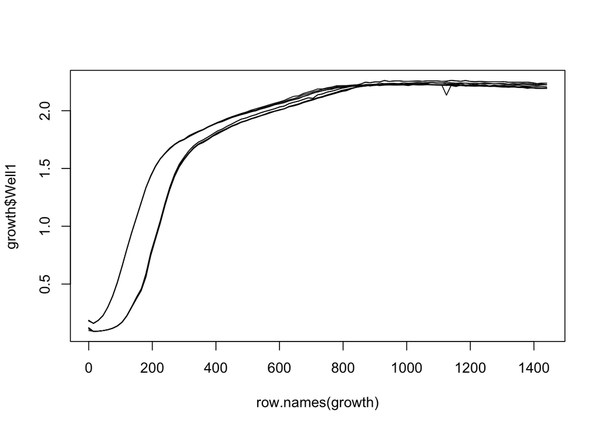

```r
plot(row.names(growth), growth$Well1, type = 'l')
apply(growth, 2, function(col){
  lines(row.names(growth), col)
})
```

### 6. Faster looping with future.apply

Here’s a [Data Camp tutorial](https://campus.datacamp.com/courses/parallel-programming-in-r/foreach-futureapply-and-load-balancing?ex=9) to learn more about paralell programming in R – specifically future and future.apply()